# predict_citibike

Aleksandra Georgievska

2023-06-19

# Description

## Day 1 - Predicting daily Citibike trips (open-ended)

- The point of this exercise is to get experience in an open-ended prediction exercise: predicting the total number of Citibike trips taken on a given day.
- Create an RMarkdown file named `predict_citibike.Rmd` and do all of your work in it.
- The rules of the game are broken into sections 1-9:
1. Use the `trips_per_day.tsv` file that has one row for each day, the number of trips taken on that day, and the minimum temperature on that day.

```r
trips_per_day <- read_tsv(here("week4/trips_per_day.tsv"), show_col_types = FALSE)

head(trips_per_day)
```

```
## # A tibble: 6 × 8
##   ymd        num_trips     date  prcp  snwd  snow  tmax  tmin
##   <date>         <dbl>    <dbl> <dbl> <dbl> <dbl> <dbl> <dbl>
## 1 2014-01-01      6059 20140101  0      0     0     3.3   2.4
## 2 2014-01-02      8600 20140102  0.33   0     3.1   3.3   1.8
## 3 2014-01-03      1144 20140103  0.29   5.9   3.3   1.8   0.9
## 4 2014-01-04      2292 20140104  0      5.9   0     2.9   0.8
## 5 2014-01-05      2678 20140105  0.14   3.9   0     4     2.7
## 6 2014-01-06      9510 20140106  0.36   1.2   0     5.5   1.9
```

2. Split the data into randomly selected training, validation, and test sets, with 90% of the data for training and validating the model, and 10% for a final test set (to be used once and only once towards the end of this exercise).
- You can adapt the code from last week’s complexity control notebook to do this.
- When comparing possible models, you can use a single validation fold or k-fold cross-validation if you’d like a more robust estimate.

```r
set.seed(45)

# get the number of rows in the data set
num_days <- nrow(trips_per_day)

# set 80% for training
frac_train <- 0.8
num_train <- floor(num_days*frac_train)

# randomly sample rows for training set
ndx <- sample(1:num_days, num_train, replace=F)

# use this data for model fitting
trips_per_day_train <- trips_per_day[ndx, ]

# split the remaining 20%, 50/50 for validation and testing
trips_per_day_20 <- trips_per_day[-ndx, ]
num_days_20 <- nrow(trips_per_day_20)
frac_val <- 0.5
num_val <- floor(num_days_20*frac_val)
ndx20 <- sample(1:num_days_20, num_val, replace=F)
trips_per_day_val <- trips_per_day_20[ndx20, ]

# save the remaining 10% as a testing data set
trips_per_day_test <- trips_per_day_20[-ndx20, ]
```

3. Start out with the model in that notebook, which uses only the minimum temperature on each day to predict the number of trips taken that day.
- Try different polynomial degrees in the minimum temperature and check that you get results similar to what’s in that notebook, although they likely won’t be identical due to shuffling of which days end up in the train, and validation splits.
- Quantify your performance using [root mean-squared error](https://www.kaggle.com/wiki/RootMeanSquaredError).

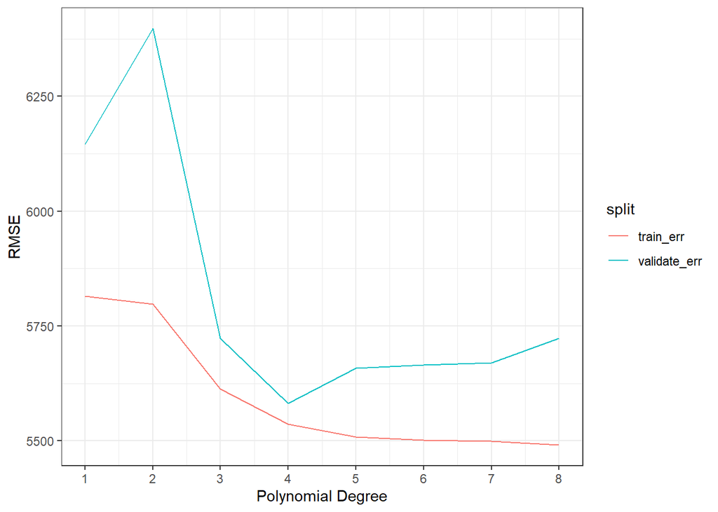

```r
# We'll evaluate models from degree 1 up through degree 8.
# For each we'll fit on the training data and evaluate on the validation data

K <- 1:8
train_err <- c()
validate_err <- c()

for (k in K) {
  # fit the model with the training data
  model <- lm(num_trips ~ poly(tmin, k, raw=T), data = trips_per_day_train)

  # evaluate on training data
  # sqrt(mean(model output - actual))
  train_err[k] <- sqrt(mean((predict(model, trips_per_day_train) - trips_per_day_train$num_trips)^2))

  # evaluate on the validate data
  validate_err[k] <- sqrt(mean((predict(model, trips_per_day_val) - trips_per_day_val$num_trips)^2))
}

#plot the training and validation error as a function of the polynomial degree.

plot_data <- data.frame(K, train_err, validate_err) %>%
  gather("split", "error", -K)

ggplot(plot_data, aes(x=K, y=error, color=split)) +
  geom_line() +
  scale_x_continuous(breaks=K) +
  xlab('Polynomial Degree') +
  ylab('RMSE')
```

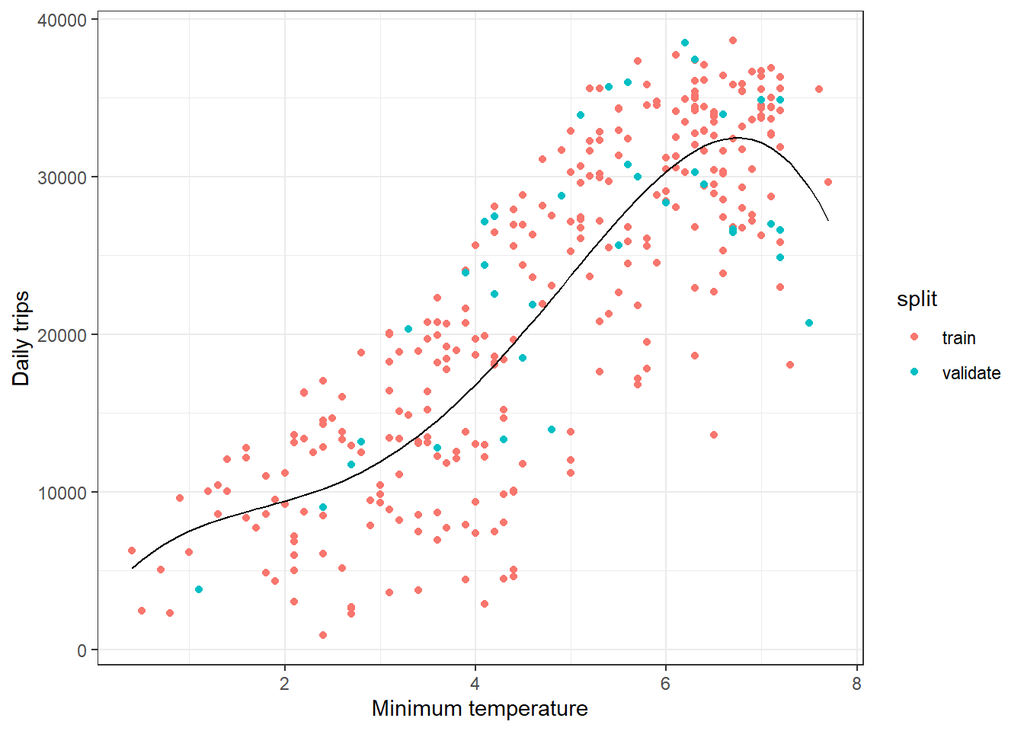

```r
# fitting a new model with all data to visualize the results
model <- lm(num_trips ~ poly(tmin, 4, raw = T), data = trips_per_day_train)

trips_per_day_train <- trips_per_day_train %>%
  add_predictions(model) %>%
  mutate(split = "train")

trips_per_day_val <- trips_per_day_val %>%
  add_predictions(model) %>%
  mutate(split = "validate")

plot_data <- bind_rows(trips_per_day_train, trips_per_day_val)

ggplot(plot_data, aes(x = tmin, y = num_trips)) +
  geom_point(aes(color = split)) +
  geom_line(aes(y = pred)) +
  xlab('Minimum temperature') +
  ylab('Daily trips') +
  scale_y_continuous()
```

4. Now get creative and extend the model to improve it.
- You can use any features you like that are available prior to the day in question, ranging from the weather, to the time of year and day of week, to activity in previous days or weeks, but don’t cheat and use features from the future (e.g., the next day’s trips).
- You can even try adding [holiday](https://gist.github.com/shivaas/4758439) effects.
- You might want to look at feature distributions to get a sense of what tranformations (e.g., `log` or manually created factors such as weekday vs. weekend) might improve model performance.
- You can also interact features with each other. This [formula syntax in R](https://cran.r-project.org/doc/manuals/R-intro.html#Formulae-for-statistical-models) reference might be useful.

```r
# adding holiday dates
holiday_dates <- read_csv(here("week4/USBank_holidays"), col_names = c('row', 'ymd', 'holiday'))
```

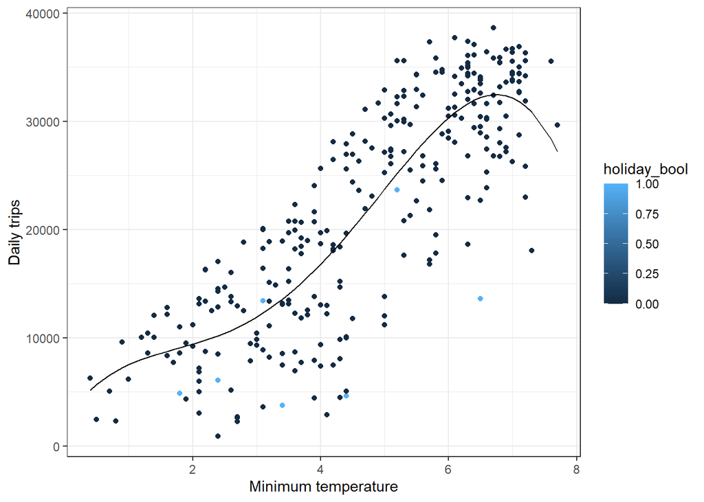

```r
# drop the first column which contains row numbers
holiday_dates <- holiday_dates[, -1]

# filter holiday_dates for dates in 2014
holiday_dates_2014 <- holiday_dates %>%
  filter(year(ymd) == 2014)

# left join
trips_per_day_train_holiday <- trips_per_day_train %>%
  left_join(holiday_dates_2014, by = c("ymd" = "ymd"))

# rename the column
trips_per_day_train_holiday <- trips_per_day_train_holiday %>%
  rename(holiday_name = holiday)

# create new boolean column to mark if holiday T/F
trips_per_day_train_holiday <- trips_per_day_train_holiday %>%
  mutate(holiday_bool = ifelse(is.na(holiday_name), 0, 1))

# plot the data with the added holidays
ggplot(trips_per_day_train_holiday, aes(x = tmin, y = num_trips)) +
  geom_point(aes(color = holiday_bool)) +
  geom_line(aes(y = pred)) +
  xlab('Minimum temperature') +
  ylab('Daily trips') +
  scale_y_continuous()
```

```r
# at first glance it looks like the model over-estimates on holidays for all except 1.
```

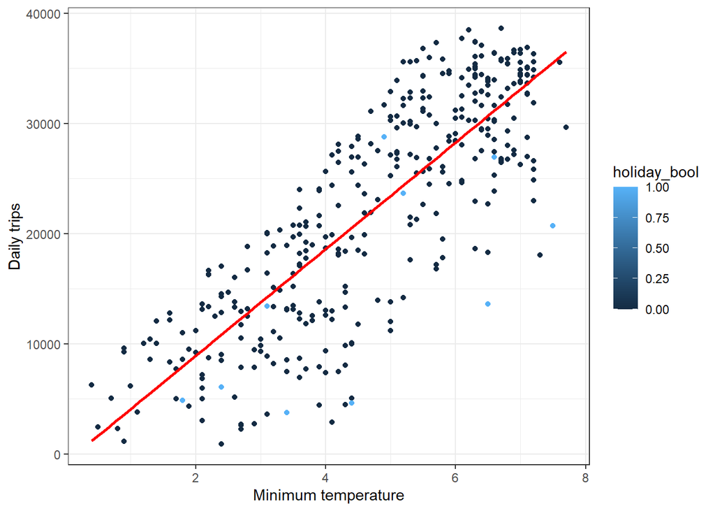

```r
# left join on original data frame
trips_per_day_holiday <- trips_per_day %>%
  left_join(holiday_dates_2014, by = c("ymd" = "ymd"))

# rename the column
trips_per_day_holiday <- trips_per_day_holiday %>%
  rename(holiday_name = holiday)

# create new boolean column to mark if holiday T/F
trips_per_day_holiday <- trips_per_day_holiday %>%
  mutate(holiday_bool = ifelse(is.na(holiday_name), 0, 1))

# plot all the 2014 data including the holidays to see where the holidays fall
ggplot(trips_per_day_holiday, aes(x = tmin, y = num_trips)) +
  geom_point(aes(color = holiday_bool)) +
  geom_smooth(method="lm", se=FALSE, color = "red") +
  xlab('Minimum temperature') +
  ylab('Daily trips') +
  scale_y_continuous()
```

## Observation:

Roughly looks like holiday daily trips are lower.

5. Try a bunch of different models and ideas, documenting them in your Rmarkdown file. Inspect the models to figure out what the highly predictive features are, and see if you can prune away any negligble features that don’t matter much. Report the model with the best performance on the validation data. Watch out for overfitting.

```r
# temp/rain
```

6. Plot your final best fit model in two different ways. First with the date on the x-axis and the number of trips on the y-axis, showing the actual values as points and predicted values as a line. Second as a plot where the x-axis is the predicted value and the y-axis is the actual value, with each point representing one day.
7. When you’re convinced that you have your best model, clean up all your code so that it saves your best model in a `.RData` file using the `save` function.
8. Commit all of your changes to git, using `git add -f` to add the model `.Rdata` file if needed, and push to your Github repository.
9. Finally, use the model you just developed and pushed to Github to make predictions on the 10% of data you kept aside as a test set. Do this only once, and record the performance in your Rmarkdown file. Use this number to make a guess as to how your model will perform on future data (which we’ll test it on!). Do you think it will do better, worse, or the same as it did on the 10% test set you used here? Write your answer in your Rmarkdown notebook. Render the notebook and push the final result to Github.